# Restricted and Prohibited Plant Species in South Africa

NEMBA TOPS Regulations, AIS Lists, and CITES — A Comprehensive Reference

Kwiz Research

07 April 2026

# Executive Summary

South Africa is one of the world’s six recognised **megadiverse** countries, harbouring approximately **10% of all plant species on Earth** in just 2% of its land area. The Cape Floristic Region — a global biodiversity hotspot — is home to over **9,600 plant species**, of which approximately **70% are endemic**. Protecting this extraordinary flora requires a multi-layered legal framework that addresses threatened native species, invasive alien plants, regulated harvest, and international trade.

This report compiles **115 plant species** subject to legal restrictions under South African law. Of these, **57** are listed under the NEMBA Threatened or Protected Species (TOPS) Regulations, **39** are designated invasive alien species (AIS) subject to compulsory control, and **19** are protected under the National Forests Act. **26** carry CITES Appendix I listings (commercial trade prohibited) and **11** are on Appendix II. **19** are Critically Endangered and **9** are Endangered on the IUCN Red List.

South Africa is one of the few African countries with a fully published, English-language threatened species list directly accessible via the Department of Forestry, Fisheries and Environment (DFFE) and SAFLII.

# 1 Legal Framework

South Africa’s plant protection regime rests on four primary legislative instruments.

## 1.1 National Environmental Management: Biodiversity Act, 2004 (NEMBA)

The **National Environmental Management: Biodiversity Act, No. 10 of 2004** (NEMBA) is South Africa’s primary legislation for biodiversity conservation. It establishes the framework for managing threatened and protected species, alien and invasive species, bioprospecting, and access and benefit sharing.

**Key NEMBA provisions for plants:**

- **Section 56 — Threatened or Protected Species:** Empowers the Minister to publish a list of threatened or protected species (TOPS). All specimens of listed species may only be possessed, traded, or otherwise processed under a TOPS permit.
- **Section 56(8) — Permit System:** TOPS permits are issued by provincial nature conservation agencies (e.g., CapeNature, Ezemvelo KZN Wildlife) and DFFE for national-level activities. Violations carry fines up to **R5 million or 10 years imprisonment**.
- **Chapter 5 — Alien and Invasive Species (AIS):** Designates species in four categories (1a compulsory eradication, 1b compulsory control, 2 permit-required, 3 prohibited) and imposes obligations on landowners to control Category 1 species.
- **Section 83 — Bioprospecting:** Regulates commercial use of indigenous biological resources (including plant-derived compounds), requiring prior informed consent and benefit-sharing agreements.

**TOPS Regulations** (Government Notice R 151, 2 February 2007, as amended): Publish the current list of threatened and protected species with their listing categories. The list is reviewed by SANBI and DFFE and updated via Gazette.

Full text: [SAFLII — NEMBA 2004](https://www.saflii.org/za/legis/num_act/nemba2004355/) | [DFFE](https://www.dffe.gov.za/legislation/actsregulations)

**⚠ Implementation Gap** — The TOPS Regulations were last comprehensively updated through GN 799/2022. However, SANBI’s National Assessment of South Africa’s Fauna and Flora (NASAFF, 2021) identified **~2,000 plant species** meeting threatened criteria under IUCN standards — far more than are currently listed in the TOPS Regulations. The TOPS list covers a fraction of IUCN-assessed threatened species, meaning the majority have no legal protection status in South Africa.

## 1.2 National Forests Act, 1998

The **National Forests Act, No. 84 of 1998** protects indigenous forests and certain tree species.

**Section 12 — Protected Trees:** The Minister may, by Gazette notice, declare any tree species as protected. Felling, damage, removal, or attempted felling of a protected tree is prohibited without a licence from a Forest Officer. The current protected trees list was published in GN R 1030 of 2004 and includes approximately 120 species.

**Section 15 — Use of State Forests:** Regulates harvesting of any forest product from state forests.

Full text: [DFFE — National Forests Act](https://www.dffe.gov.za/legislation/actsregulations/forests)

## 1.3 National Environmental Management: Biodiversity Act — AIS Regulations, 2020

The **Alien and Invasive Species Regulations** (GN No. R. 1003, 30 September 2020) under NEMBA designate invasive species in four categories:

| Category | Description | Obligation |
| --- | --- | --- |
| **1a** | Species with no socio-economic benefit; must be eradicated | Compulsory removal and destruction |
| **1b** | Invasive; causes ecological/economic harm | Compulsory control on all land |
| **2** | Invasive in certain habitats; some permitted uses | Permit required for keeping or trade |
| **3** | Potentially invasive; prohibited from new planting | Existing specimens exempt under permit |

Categories 1a and 1b impose a legal duty on landowners to control listed species on their property. Failure to comply allows the responsible authority to carry out the work and recover costs from the landowner.

Full text: [GN R. 1003/2020](https://www.gov.za/documents/national-environmental-management-biodiversity-act-alien-and-invasive-species-regulations)

## 1.4 CITES Implementation in South Africa

South Africa ratified CITES in 1975. DFFE is the designated Management Authority. CITES is implemented domestically through NEMBA regulations.

South Africa hosts significant populations of CITES-listed plant species including all *Encephalartos* (Appendix I), all *Aloe* (Appendix II), all Orchidaceae, all Euphorbia (succulent spp.), and all Cactaceae.

**⚠ Implementation Gap** — South Africa is both a source and transit country for illegal wildlife products. Cycad poaching from wild populations has reached critical levels: in 2019–2022 alone, **over 100 TOPS permit violations** were documented by SANBI involving cycad theft from state land. The courts have imposed fines but rarely custodial sentences, reducing the deterrent effect of the legislation.

# 2 Regional / Subnational Restrictions

South Africa’s Constitution (Schedule 4) places environment, nature conservation, and pollution as **concurrent national and provincial competencies**. Each of South Africa’s 9 provinces has its own conservation legislation — mostly pre-democratic ordinances from the Apartheid era that have been partially retained, partially repealed, and partly superseded by post-1994 national laws. The **National Environmental Management: Biodiversity Act (NEMBA, 2004)** and **TOPS Regulations** establish national minimums; provinces may be stricter.

## 2.1 Provincial Conservation Legislation

[output not shown]

## 2.2 Western Cape — Fynbos Biome Special Regime

The **Cape Floristic Region** (a UNESCO World Heritage site) has the world’s highest plant diversity for its area — approximately 9,600 species in ~88,000 km². CapeNature maintains dedicated protected plant lists with three tiers:

1. **Protected Plant List A** — may not be collected, damaged, transported, or traded without CapeNature permit (applies outside protected areas)
2. **Protected Plant List B** — restricted harvest permits for commercial use
3. **Protected Plant List C** — notification required for commercial harvest

Commercially important species like *Agathosma betulina* (buchu — essential oil), *Aspalathus linearis* (rooibos — tea), and *Cyclopia* (honeybush) are subject to dedicated Wild Harvest Protocols under the **Rooibos Industry Development Trust** and CapeNature permit requirements.

## 2.3 Traditional Use and Medicinal Plant Markets

South Africa’s Constitution (Section 211) recognises traditional communities’ rights. **Medicinal plant (muthi) trade** is a multi-billion rand industry — primarily regulated at provincial level:

- **KZN Ezemvelo**: Warwick Avenue medicinal plant market in Durban — periodic inspections and TOPS compliance checks
- **Gauteng GDARD**: Faraday Street muthi market — monitoring under Traditional Healers and Medicinal Plants Task Team
- Key traded species with provincial monitoring: *Prunus africana* bark, cycad seeds, *Hypoxis hemerocallidea* (African potato), *Siphonochilus aethiopicus* (wild ginger)

**Source note** — CapeNature: capenature.co.za | Ezemvelo KZN Wildlife: kznwildlife.com | SANBI TOPS: [sanbi.org/biodiversity/foundations-research/plant-conservation/tops/](https://www.sanbi.org) | GDARD: gdard.gpg.gov.za.

# 3 Regulatory Institutions

Table 1. Institutions with Plant Species Regulatory Mandates in South Africa

| abbreviation | institution_name | parent_ministry | mandate |
| --- | --- | --- | --- |
| DFFE | Dept of Forestry, Fisheries and Environment | The Presidency | Primary environmental regulator; issues TOPS and AIS permits; manages protected trees; CITES Management Authority |
| SANBI | South African National Biodiversity Institute | DFFE | Biodiversity science; TOPS species assessments; GBIF node; manages 9 national botanical gardens; Red List authority |
| SANParks | South African National Parks | DFFE | Manages 20 national parks; in-situ conservation; law enforcement within park boundaries |
| CapeNature | Western Cape Nature Conservation Board | Western Cape Province | Issues TOPS permits in Western Cape; manages provincial nature reserves; fynbos species enforcement |
| Ezemvelo | Ezemvelo KZN Wildlife | KwaZulu-Natal Province | Issues TOPS permits in KZN; manages 80+ nature reserves; grassland and coastal species enforcement |
| DAFF | Dept of Agriculture, Land Reform and Rural Dev | DALRRD | Plant Health Directorate; AIS control on agricultural land; invasive species awareness |
| SANBI-GBIF | South African GBIF Node (SANBI) | SANBI / DFFE | Biodiversity data infrastructure; maintains BioNET-SA portal; publishes GBIF occurrence data |
| LAPES | Legal Affairs and Permits (NEMBA) | DFFE | Administers TOPS and AIS national permit system; processes Appendix I CITES import/export applications |

# 4 Comprehensive Plant Species Listing

The master listing covers **115 plant species** subject to legal restriction under South African law. This includes threatened and protected native species (TOPS), invasive alien species (AIS), protected trees, and CITES-listed taxa.

## 4.1 Overview by Category

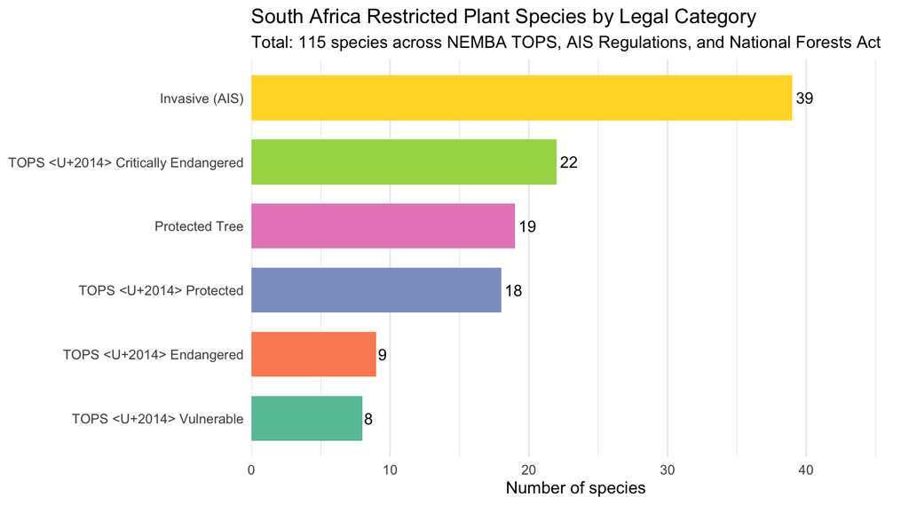

Species count by South African legal classification.

## 4.2 Master Species Table

Table 2. Comprehensive Restricted/Protected Plant Species in South Africa

| Common Name | Scientific Name | Group | IUCN Status | CITES | SA Legal Status | Governing Law | Managing Inst. | Notes |
| --- | --- | --- | --- | --- | --- | --- | --- | --- |
| American bramble | *Rubus cuneifolius* | Magnoliopsida | Least Concern | Not listed | Category 1b Invasive | NEMBA AIS Regulations 2020 | DFFE / DAFF | Grassland and forest margin; Mpumalanga/KZN; thorny thickets |
| Australian blackwood | *Acacia melanoxylon* | Magnoliopsida | Least Concern | Not listed | Category 2 Invasive (permit) | NEMBA AIS Regulations 2020 | DFFE / DAFF | Invades forest margins and riparian areas; some commercial forestry |
| Black wattle | *Acacia mearnsii* | Magnoliopsida | Least Concern | Not listed | Category 2 Invasive (permit) | NEMBA AIS Regulations 2020 | DFFE / DAFF | Massive water user; transforms fynbos and grassland; some commercial use |
| Brazilian pepper | *Schinus terebinthifolia* | Magnoliopsida | Least Concern | Not listed | Category 1b Invasive | NEMBA AIS Regulations 2020 | DFFE / DAFF | Coastal KZN invader; bird-dispersed; dense riverine thickets |
| Bugweed | *Solanum mauritianum* | Magnoliopsida | Least Concern | Not listed | Category 1b Invasive | NEMBA AIS Regulations 2020 | DFFE / DAFF | Major forest margin invader; KZN/Mpumalanga; bird-dispersed |
| Camphor tree | *Cinnamomum camphora* | Magnoliopsida | Least Concern | Not listed | Category 1b Invasive | NEMBA AIS Regulations 2020 | DFFE / DAFF | Invades KZN/EC forests and coastal areas; bird-dispersed |
| Castor oil plant | *Ricinus communis* | Magnoliopsida | Least Concern | Not listed | Category 2 Invasive (permit) | NEMBA AIS Regulations 2020 | DFFE / DAFF | Riverbank invader; toxic seeds; commercial oil production permitted |
| Common lantana | *Lantana camara* | Magnoliopsida | Least Concern | Not listed | Category 1b Invasive | NEMBA AIS Regulations 2020 | DFFE / DAFF | Major invasive in KZN and Limpopo riparian zones; toxic berries |
| Eucalyptus (various) | *Eucalyptus camaldulensis* | Magnoliopsida | Least Concern | Not listed | Category 2 Invasive (permit) | NEMBA AIS Regulations 2020 | DFFE / DAFF | River red gum; massive water consumer; riparian zone invader |
| Giant reed | *Arundo donax* | Magnoliopsida | Least Concern | Not listed | Category 1b Invasive | NEMBA AIS Regulations 2020 | DFFE / DAFF | Invades rivers and wetlands nationwide; water consumption |
| Honey mesquite | *Prosopis glandulosa* | Magnoliopsida | Least Concern | Not listed | Category 1b Invasive | NEMBA AIS Regulations 2020 | DFFE / DAFF | Dryland invasive; millions of ha in Northern Cape; water table impact |
| Jacaranda | *Jacaranda mimosifolia* | Magnoliopsida | Least Concern | Not listed | Category 3 Invasive (no new planting) | NEMBA AIS Regulations 2020 | DFFE / DAFF | Iconic Pretoria street tree; no new plantings allowed; heritage debate |
| Jointed cactus | *Opuntia aurantiaca* | Magnoliopsida | Least Concern | Not listed | Category 1b Invasive | NEMBA AIS Regulations 2020 | DFFE / DAFF | Eastern Cape grassland invader; livestock injury; biocontrol deployed |
| Kariba weed | *Salvinia auriculata* | Polypodiopsida | Least Concern | Not listed | Category 1b Invasive | NEMBA AIS Regulations 2020 | DFFE / DAFF | Floating fern; dam surfaces; confused with S. molesta; both controlled |
| Long-leaved wattle | *Acacia longifolia* | Magnoliopsida | Least Concern | Not listed | Category 1b Invasive | NEMBA AIS Regulations 2020 | DFFE / DAFF | Coastal dune invader; Western/Eastern Cape; displaces dune fynbos |
| Mauritius thorn | *Caesalpinia decapetala* | Magnoliopsida | Least Concern | Not listed | Category 1b Invasive | NEMBA AIS Regulations 2020 | DFFE / DAFF | Dense thorny thickets in KZN/Mpumalanga river valleys |
| Parrot’s feather | *Myriophyllum aquaticum* | Magnoliopsida | Least Concern | Not listed | Category 1b Invasive | NEMBA AIS Regulations 2020 | DFFE / DAFF | Submerged aquatic; chokes waterways; ornamental escape |
| Parthenium weed | *Parthenium hysterophorus* | Magnoliopsida | Least Concern | Not listed | Category 1b Invasive | NEMBA AIS Regulations 2020 | DFFE / DAFF | Recent arrival spreading through Limpopo/Mpumalanga; allergen |
| Pine species (patula) | *Pinus patula* | Pinopsida | Least Concern | Not listed | Category 2 Invasive (permit) | NEMBA AIS Regulations 2020 | DFFE / DAFF | Major forestry species; invades grassland and fynbos margins |
| Pine species (pinaster) | *Pinus pinaster* | Pinopsida | Least Concern | Not listed | Category 2 Invasive (permit) | NEMBA AIS Regulations 2020 | DFFE / DAFF | Invades Western Cape fynbos extensively; Working for Water target |
| Pine species (radiata) | *Pinus radiata* | Pinopsida | Least Concern | Not listed | Category 2 Invasive (permit) | NEMBA AIS Regulations 2020 | DFFE / DAFF | Plantation species; invades fynbos and grassland; water impacts |
| Pompom weed | *Campuloclinium macrocephalum* | Magnoliopsida | Least Concern | Not listed | Category 1b Invasive | NEMBA AIS Regulations 2020 | DFFE / DAFF | Gauteng/Mpumalanga grassland invader; displaces native forbs |
| Poplar (various) | *Populus canescens* | Magnoliopsida | Least Concern | Not listed | Category 2 Invasive (permit) | NEMBA AIS Regulations 2020 | DFFE / DAFF | Grey poplar; riparian invader; root suckers spread aggressively |
| Port Jackson willow | *Acacia saligna* | Magnoliopsida | Least Concern | Not listed | Category 1b Invasive | NEMBA AIS Regulations 2020 | DFFE / DAFF | Transforms fynbos; biological control agents deployed (gall rust) |
| Queen of the night cactus | *Cereus jamacaru* | Magnoliopsida | Least Concern | Not listed | Category 1b Invasive | NEMBA AIS Regulations 2020 | DFFE / DAFF | Limpopo/Northern Cape; tall columnar; spreading along fence lines |
| Red water fern | *Azolla filiculoides* | Polypodiopsida | Least Concern | Not listed | Category 1b Invasive | NEMBA AIS Regulations 2020 | DFFE / DAFF | Floating fern; nitrogen fixer; deoxygenates water bodies |
| Rooikrans | *Acacia cyclops* | Magnoliopsida | Least Concern | Not listed | Category 1b Invasive | NEMBA AIS Regulations 2020 | DFFE / DAFF | Dominant coastal dune invader in Western/Southern Cape |
| Salvinia | *Salvinia molesta* | Polypodiopsida | Least Concern | Not listed | Category 1b Invasive | NEMBA AIS Regulations 2020 | DFFE / DAFF | Floating fern; smothers dams and irrigation canals; biocontrol deployed |
| Scotch broom | *Cytisus scoparius* | Magnoliopsida | Least Concern | Not listed | Category 1b Invasive | NEMBA AIS Regulations 2020 | DFFE / DAFF | Invades grasslands in Mpumalanga/KZN highveld |
| Silky hakea | *Hakea sericea* | Magnoliopsida | Least Concern | Not listed | Category 1b Invasive | NEMBA AIS Regulations 2020 | DFFE / DAFF | Dense fynbos invader; Cederberg and Agulhas; fire adapted |

[output cut: 85 more lines]

## 4.3 TOPS — Critically Endangered and Endangered Species

The TOPS Critically Endangered and Endangered categories represent the highest tier of domestic legal protection. Trade, possession, and collection of these species requires a TOPS permit (and Appendix I species additionally require CITES permits). In practice, for many Critically Endangered species, no trade is permitted.

Table 3. TOPS Critically Endangered and Endangered Plant Species (31 species)

| Common Name | Scientific Name | IUCN | CITES | SA Status | Notes |
| --- | --- | --- | --- | --- | --- |
| Albany cycad | *Encephalartos latifrons* | Critically Endangered | Appendix I | Critically Endangered (TOPS) | Most endangered cycad globally; heavily poached; Eastern Cape |
| Blue Drakensberg cycad | *Encephalartos nubimontanus* | Critically Endangered | Appendix I | Critically Endangered (TOPS) | Drakensberg endemic; <100 plants in wild |
| Cerulean cycad | *Encephalartos cerinus* | Critically Endangered | Appendix I | Critically Endangered (TOPS) | Limpopo; fewer than 60 plants known |
| Clanwilliam cedar | *Widdringtonia cedarbergensis* | Critically Endangered | Not listed | Critically Endangered (TOPS) | Cederberg endemic; <100 mature trees; fire and climate change |
| Cupidus cycad | *Encephalartos cupidus* | Critically Endangered | Appendix I | Critically Endangered (TOPS) | Limpopo; <300 individuals; cliff habitat |
| Cycad (msinganus) | *Encephalartos msinganus* | Critically Endangered | Appendix I | Critically Endangered (TOPS) | KZN Msinga area; discovered 2003; very restricted range |
| Dolomite cycad | *Encephalartos dolomiticus* | Critically Endangered | Appendix I | Critically Endangered (TOPS) | Wolkberg dolomite cliffs; very few plants; climbing poachers |
| Eastern Cape blue cycad | *Encephalartos princeps* | Critically Endangered | Appendix I | Critically Endangered (TOPS) | Eastern Cape endemic; extreme poaching pressure |
| Elim conebush | *Leucadendron elimense* | Critically Endangered | Not listed | Critically Endangered (TOPS) | Three surviving subpopulations; Agulhas Plain endemic |
| Fragrant sugarbush | *Protea odorata* | Critically Endangered | Not listed | Critically Endangered (TOPS) | <250 mature plants in Swartland fynbos |
| Heenani cycad | *Encephalartos heenanii* | Critically Endangered | Appendix I | Critically Endangered (TOPS) | Mpumalanga escarpment; <100 wild individuals |
| Inopinus cycad | *Encephalartos inopinus* | Critically Endangered | Appendix I | Critically Endangered (TOPS) | Limpopo; <200 plants; restricted rocky habitat |
| Laevifolius cycad | *Encephalartos laevifolius* | Critically Endangered | Appendix I | Critically Endangered (TOPS) | Mpumalanga/Limpopo; grassland; population plummeted from poaching |
| Middleburg cycad | *Encephalartos middelburgensis* | Critically Endangered | Appendix I | Critically Endangered (TOPS) | Mpumalanga grassland endemic; severely poached |
| Mimetes stokoei | *Mimetes stokoei* | Critically Endangered | Not listed | Critically Endangered (TOPS) | Kogelberg pagoda; rediscovered 2010 after believed extinct; <50 plants |
| Serruria furcellata | *Serruria furcellata* | Critically Endangered | Not listed | Critically Endangered (TOPS) | Scarlet spiderhead; Cape Flats lowland fynbos; urbanisation threat |
| Transvaal cycad | *Encephalartos dyerianus* | Critically Endangered | Appendix I | Critically Endangered (TOPS) | Limpopo; very few in wild outside cultivation |
| Venda cycad | *Encephalartos hirsutus* | Critically Endangered | Appendix I | Critically Endangered (TOPS) | Limpopo endemic; limited remaining wild population |
| Wild ginger | *Siphonochilus aethiopicus* | Critically Endangered | Not listed | Critically Endangered (TOPS) | Extinct from wild in KZN/Gauteng; muthi trade; rhizome harvested |
| Bastard quiver tree | *Aloe pillansii* | Endangered | Appendix II | Endangered (TOPS) | Northern Cape; declining from climate change; no recruitment observed |
| Cycad (eugene-maraisii) | *Encephalartos eugene-maraisii* | Endangered | Appendix I | Endangered (TOPS) | Waterberg, Limpopo; glaucous blue leaves; heavily poached |
| Cycad (horridus) | *Encephalartos horridus* | Endangered | Appendix I | Endangered (TOPS) | Eastern Cape; spiny blue leaves; heavily traded in succulent market |
| Giant quiver tree | *Aloidendron pillansii* | Endangered | Appendix II | Endangered (TOPS) | Richtersveld; tallest aloe; <200 reproductive individuals |
| Marsh rose / Orothamnus | *Orothamnus zeyheri* | Endangered | Not listed | Endangered (TOPS) | Fernkloof/Kogelberg endemic; marshy fynbos; very restricted range |
| Pepper-bark tree | *Warburgia salutaris* | Endangered | Not listed | Endangered (TOPS) | Bark heavily harvested for traditional medicine; functionally extinct in KZN |
| Piet Retief cycad | *Encephalartos arenarius* | Endangered | Appendix I | Endangered (TOPS) | Eastern Cape coastal dunes; sand-dwelling; few hundred plants |
| Pondo coconut | *Jubaeopsis caffra* | Endangered | Not listed | Endangered (TOPS) | World’s rarest palm; <500 plants on Wild Coast, Eastern Cape |
| Snow protea | *Protea cryophila* | Endangered | Not listed | Endangered (TOPS) | Swartberg high-altitude endemic; climate change vulnerable |
| Barberton cycad | *Encephalartos brevifoliolatus* | Extinct in the Wild | Appendix I | Critically Endangered (TOPS) | Extinct in wild (poached); Barberton; only garden specimens survive |
| Whorled heath | *Erica verticillata* | Extinct in the Wild | Not listed | Critically Endangered (TOPS) | Extinct in wild; maintained in Kirstenbosch ex-situ collections |
| Wood’s cycad | *Encephalartos woodii* | Extinct in the Wild | Appendix I | Critically Endangered (TOPS) | Extinct in wild; only male plants known; clones in botanic gardens |

## 4.4 Invasive Alien Species (AIS)

The AIS Regulations designate Category 1 invasive plants for compulsory control. Landowners are legally obligated to control or eradicate these species on their property. DFFE and DAFF manage the Working for Water programme, one of the world’s largest invasive species control initiatives (~40,000 ha cleared annually).

| Common Name | Scientific Name | AIS Category | Restriction | Notes |
| --- | --- | --- | --- | --- |
| American bramble | *Rubus cuneifolius* | Category 1b Invasive | Compulsory control/removal | Grassland and forest margin; Mpumalanga/KZN; thorny thickets |
| Australian blackwood | *Acacia melanoxylon* | Category 2 Invasive (permit) | Permit required; control outside designated areas | Invades forest margins and riparian areas; some commercial forestry |
| Black wattle | *Acacia mearnsii* | Category 2 Invasive (permit) | Permit required; control outside designated areas | Massive water user; transforms fynbos and grassland; some commercial use |
| Brazilian pepper | *Schinus terebinthifolia* | Category 1b Invasive | Compulsory control/removal | Coastal KZN invader; bird-dispersed; dense riverine thickets |
| Bugweed | *Solanum mauritianum* | Category 1b Invasive | Compulsory control/removal | Major forest margin invader; KZN/Mpumalanga; bird-dispersed |
| Camphor tree | *Cinnamomum camphora* | Category 1b Invasive | Compulsory control/removal | Invades KZN/EC forests and coastal areas; bird-dispersed |
| Castor oil plant | *Ricinus communis* | Category 2 Invasive (permit) | Permit required; control where invading | Riverbank invader; toxic seeds; commercial oil production permitted |
| Common lantana | *Lantana camara* | Category 1b Invasive | Compulsory control/removal | Major invasive in KZN and Limpopo riparian zones; toxic berries |
| Eucalyptus (various) | *Eucalyptus camaldulensis* | Category 2 Invasive (permit) | Permit for plantation; control in riparian zones | River red gum; massive water consumer; riparian zone invader |
| Giant reed | *Arundo donax* | Category 1b Invasive | Compulsory control/removal | Invades rivers and wetlands nationwide; water consumption |
| Honey mesquite | *Prosopis glandulosa* | Category 1b Invasive | Compulsory control/removal | Dryland invasive; millions of ha in Northern Cape; water table impact |
| Jacaranda | *Jacaranda mimosifolia* | Category 3 Invasive (no new planting) | No new plantings; existing trees tolerated | Iconic Pretoria street tree; no new plantings allowed; heritage debate |
| Jointed cactus | *Opuntia aurantiaca* | Category 1b Invasive | Compulsory control/removal | Eastern Cape grassland invader; livestock injury; biocontrol deployed |
| Kariba weed | *Salvinia auriculata* | Category 1b Invasive | Compulsory control/removal | Floating fern; dam surfaces; confused with S. molesta; both controlled |
| Long-leaved wattle | *Acacia longifolia* | Category 1b Invasive | Compulsory control/removal | Coastal dune invader; Western/Eastern Cape; displaces dune fynbos |
| Mauritius thorn | *Caesalpinia decapetala* | Category 1b Invasive | Compulsory control/removal | Dense thorny thickets in KZN/Mpumalanga river valleys |
| Parrot’s feather | *Myriophyllum aquaticum* | Category 1b Invasive | Compulsory control/removal | Submerged aquatic; chokes waterways; ornamental escape |
| Parthenium weed | *Parthenium hysterophorus* | Category 1b Invasive | Compulsory control/removal | Recent arrival spreading through Limpopo/Mpumalanga; allergen |
| Pine species (patula) | *Pinus patula* | Category 2 Invasive (permit) | Permit for plantation; control in fynbos | Major forestry species; invades grassland and fynbos margins |
| Pine species (pinaster) | *Pinus pinaster* | Category 2 Invasive (permit) | Permit for plantation; control in fynbos | Invades Western Cape fynbos extensively; Working for Water target |
| Pine species (radiata) | *Pinus radiata* | Category 2 Invasive (permit) | Permit for plantation; control in fynbos | Plantation species; invades fynbos and grassland; water impacts |
| Pompom weed | *Campuloclinium macrocephalum* | Category 1b Invasive | Compulsory control/removal | Gauteng/Mpumalanga grassland invader; displaces native forbs |
| Poplar (various) | *Populus canescens* | Category 2 Invasive (permit) | Permit required; control in riparian zones | Grey poplar; riparian invader; root suckers spread aggressively |
| Port Jackson willow | *Acacia saligna* | Category 1b Invasive | Compulsory control/removal | Transforms fynbos; biological control agents deployed (gall rust) |
| Queen of the night cactus | *Cereus jamacaru* | Category 1b Invasive | Compulsory control/removal | Limpopo/Northern Cape; tall columnar; spreading along fence lines |
| Red water fern | *Azolla filiculoides* | Category 1b Invasive | Compulsory control/removal | Floating fern; nitrogen fixer; deoxygenates water bodies |
| Rooikrans | *Acacia cyclops* | Category 1b Invasive | Compulsory control/removal | Dominant coastal dune invader in Western/Southern Cape |
| Salvinia | *Salvinia molesta* | Category 1b Invasive | Compulsory control/removal | Floating fern; smothers dams and irrigation canals; biocontrol deployed |
| Scotch broom | *Cytisus scoparius* | Category 1b Invasive | Compulsory control/removal | Invades grasslands in Mpumalanga/KZN highveld |
| Silky hakea | *Hakea sericea* | Category 1b Invasive | Compulsory control/removal | Dense fynbos invader; Cederberg and Agulhas; fire adapted |
| Silver wattle | *Acacia dealbata* | Category 1b Invasive | Compulsory control/removal | Invades riparian zones in Western Cape and KZN; fire risk |
| Spanish reed | *Arundo donax var. versicolor* | Category 1b Invasive | Compulsory control/removal | Variegated form; ornamental escape; same impacts as type |
| Sweet hakea | *Hakea drupacea* | Category 1b Invasive | Compulsory control/removal | Invades fynbos; dense thickets; biocontrol limited |
| Sweet prickly pear | *Opuntia ficus-indica* | Category 1b Invasive | Compulsory control/removal | Extensively naturalised in Karoo; Cactoblastis biocontrol ongoing |
| Syringa / Persian lilac | *Melia azedarach* | Category 3 Invasive (no new planting) | No new plantings; existing trees tolerated | Widespread urban tree; toxic berries; riverbank invader |
| Triffid weed | *Chromolaena odorata* | Category 1b Invasive | Compulsory control/removal | Major KZN/Mpumalanga invader; transforms forest margins; fire risk |
| Velvet mesquite | *Prosopis velutina* | Category 1b Invasive | Compulsory control/removal | Northern Cape arid zone; hybridises with P. glandulosa |
| Water hyacinth | *Eichhornia crassipes* | Category 1b Invasive | Compulsory control/removal | Major threat to water bodies; fastest growing aquatic weed |
| Water lettuce | *Pistia stratiotes* | Category 1b Invasive | Compulsory control/removal | Floating aquatic weed; blocks waterways; Limpopo/Mpumalanga |

## 4.5 GBIF Backbone Resolution

The table below resolves South Africa’s regulated plant species against the GBIF Backbone Taxonomy. English vernacular names and synonyms are fetched from the GBIF `name_usage()` API.

**Resolution:** 115 of 115 species matched across 43 families.

| # | Scientific Name | Common Name | Family | GBIF Key | SA Status | Synonyms | IUCN |
| --- | --- | --- | --- | --- | --- | --- | --- |
| 1 | [*Encephalartos latifrons*](https://www.gbif.org/species/2683697) | Albany Cycad | Zamiaceae | 2683697 | Critically Endangered (TOPS) | Encephalartos horridus latifrons | [IUCN ↗](https://www.iucnredlist.org/search?query=Encephalartos%20latifrons) |
| 2 | [*Encephalartos woodii*](https://www.gbif.org/species/10096333) | Wood’s cycad | Zamiaceae | 10096333 | Critically Endangered (TOPS) | Encephalartos altensteinii bispinnus | [IUCN ↗](https://www.iucnredlist.org/search?query=Encephalartos%20woodii) |
| 3 | [*Encephalartos nubimontanus*](https://www.gbif.org/species/2683831) | Blue Cycad | Zamiaceae | 2683831 | Critically Endangered (TOPS) | Encephalartos venetus | [IUCN ↗](https://www.iucnredlist.org/search?query=Encephalartos%20nubimontanus) |
| 4 | [*Encephalartos princeps*](https://www.gbif.org/species/2683827) | Kei Cycad | Zamiaceae | 2683827 | Critically Endangered (TOPS) |  | [IUCN ↗](https://www.iucnredlist.org/search?query=Encephalartos%20princeps) |
| 5 | [*Encephalartos hirsutus*](https://www.gbif.org/species/2683802) | Venda Cycad | Zamiaceae | 2683802 | Critically Endangered (TOPS) |  | [IUCN ↗](https://www.iucnredlist.org/search?query=Encephalartos%20hirsutus) |
| 6 | [*Encephalartos dyerianus*](https://www.gbif.org/species/2683774) | Lillie Cycad, Lowveld Cycad | Zamiaceae | 2683774 | Critically Endangered (TOPS) | Encephalartos graniticola | [IUCN ↗](https://www.iucnredlist.org/search?query=Encephalartos%20dyerianus) |
| 7 | [*Encephalartos cerinus*](https://www.gbif.org/species/2683793) | Waxen Cycad | Zamiaceae | 2683793 | Critically Endangered (TOPS) |  | [IUCN ↗](https://www.iucnredlist.org/search?query=Encephalartos%20cerinus) |
| 8 | [*Encephalartos inopinus*](https://www.gbif.org/species/2683758) | Lydenburg Cycad | Zamiaceae | 2683758 | Critically Endangered (TOPS) |  | [IUCN ↗](https://www.iucnredlist.org/search?query=Encephalartos%20inopinus) |
| 9 | [*Encephalartos dolomiticus*](https://www.gbif.org/species/2683677) | Wolkberg Cycad | Zamiaceae | 2683677 | Critically Endangered (TOPS) | Encephalartos verrucosus | [IUCN ↗](https://www.iucnredlist.org/search?query=Encephalartos%20dolomiticus) |
| 10 | [*Encephalartos brevifoliolatus*](https://www.gbif.org/species/2683755) | Escarpment Cycad | Zamiaceae | 2683755 | Critically Endangered (TOPS) |  | [IUCN ↗](https://www.iucnredlist.org/search?query=Encephalartos%20brevifoliolatus) |
| 11 | [*Encephalartos heenanii*](https://www.gbif.org/species/2683721) | Heenan’s Cycad, Woolly Cycad | Zamiaceae | 2683721 | Critically Endangered (TOPS) |  | [IUCN ↗](https://www.iucnredlist.org/search?query=Encephalartos%20heenanii) |
| 12 | [*Encephalartos middelburgensis*](https://www.gbif.org/species/9848396) | Middelburg Cycad | Zamiaceae | 9848396 | Critically Endangered (TOPS) | Encephalartos eugene-maraisii middelburgensis | [IUCN ↗](https://www.iucnredlist.org/search?query=Encephalartos%20middelburgensis) |
| 13 | [*Encephalartos cupidus*](https://www.gbif.org/species/2683753) | Blyde River Cycad | Zamiaceae | 2683753 | Critically Endangered (TOPS) |  | [IUCN ↗](https://www.iucnredlist.org/search?query=Encephalartos%20cupidus) |
| 14 | [*Encephalartos laevifolius*](https://www.gbif.org/species/2683824) | Kaapsehoop Cycad | Zamiaceae | 2683824 | Critically Endangered (TOPS) |  | [IUCN ↗](https://www.iucnredlist.org/search?query=Encephalartos%20laevifolius) |
| 15 | [*Encephalartos transvenosus*](https://www.gbif.org/species/2683776) | Modjadji Cycad | Zamiaceae | 2683776 | Protected (TOPS) |  | [IUCN ↗](https://www.iucnredlist.org/search?query=Encephalartos%20transvenosus) |
| 16 | [*Encephalartos altensteinii*](https://www.gbif.org/species/2683722) | Eastern Cape Cycad, Eastern Cape Giant Cycad, prickly cycad | Zamiaceae | 2683722 | Protected (TOPS) | Bombax encephalartos, Encephalartos altensteinii altensteinii, Encephalartos … | [IUCN ↗](https://www.iucnredlist.org/search?query=Encephalartos%20altensteinii) |
| 17 | [*Encephalartos natalensis*](https://www.gbif.org/species/2683756) | Natal Cycad, Natal Giant Cycad | Zamiaceae | 2683756 | Protected (TOPS) |  | [IUCN ↗](https://www.iucnredlist.org/search?query=Encephalartos%20natalensis) |
| 18 | [*Encephalartos lehmannii*](https://www.gbif.org/species/2683786) | Karoo Cycad | Zamiaceae | 2683786 | Protected (TOPS) | Encephalartos elongatus, Encephalartos lehmannii dentatus, Encephalartos lehm… | [IUCN ↗](https://www.iucnredlist.org/search?query=Encephalartos%20lehmannii) |
| 19 | [*Encephalartos lebomboensis*](https://www.gbif.org/species/2683742) | Lebombo Cycad | Zamiaceae | 2683742 | Protected (TOPS) |  | [IUCN ↗](https://www.iucnredlist.org/search?query=Encephalartos%20lebomboensis) |
| 20 | [*Encephalartos arenarius*](https://www.gbif.org/species/2683711) | Alexandria Cycad, Dune Cycad | Zamiaceae | 2683711 | Endangered (TOPS) |  | [IUCN ↗](https://www.iucnredlist.org/search?query=Encephalartos%20arenarius) |
| 21 | [*Encephalartos horridus*](https://www.gbif.org/species/2683807) | Eastern Cape Blue Cycad | Zamiaceae | 2683807 | Endangered (TOPS) | Encephalartos altensteinii eriocephalus, Encephalartos horridus hallianus, En… | [IUCN ↗](https://www.iucnredlist.org/search?query=Encephalartos%20horridus) |
| 22 | [*Encephalartos longifolius*](https://www.gbif.org/species/2683759) | Suurberg Cycad, Thunberg’s Cycad | Zamiaceae | 2683759 | Protected (TOPS) | Encephalartos horridus lanuginosus, Encephalartos lanuginosus, Encephalartos … | [IUCN ↗](https://www.iucnredlist.org/search?query=Encephalartos%20longifolius) |
| 23 | [*Encephalartos villosus*](https://www.gbif.org/species/2683794) | Poor Man’s Cycad | Zamiaceae | 2683794 | Protected (TOPS) | Encephalartos plumosus, Encephalartos striatus, Encephalartos villosus interm… | [IUCN ↗](https://www.iucnredlist.org/search?query=Encephalartos%20villosus) |
| 24 | [*Encephalartos eugene-maraisii*](https://www.gbif.org/species/2683745) | Waterberg Cycad | Zamiaceae | 2683745 | Endangered (TOPS) | Encephalartos eugene-maraisii eugene-maraisii | [IUCN ↗](https://www.iucnredlist.org/search?query=Encephalartos%20eugene-maraisii) |
| 25 | [*Encephalartos msinganus*](https://www.gbif.org/species/2683709) | Msinga Cycad | Zamiaceae | 2683709 | Critically Endangered (TOPS) |  | [IUCN ↗](https://www.iucnredlist.org/search?query=Encephalartos%20msinganus) |
| 26 | [*Widdringtonia cedarbergensis*](https://www.gbif.org/species/2684266) | Cape Cedar, Cape-cedar, Clanwilliam Cedar, Clanwilliam Cypress, Clanwilliam-cedar | Cupressaceae | 2684266 | Critically Endangered (TOPS) | Callitris arborea, Widdringtonia juniperoides | [IUCN ↗](https://www.iucnredlist.org/search?query=Widdringtonia%20cedarbergensis) |
| 27 | [*Protea odorata*](https://www.gbif.org/species/5637028) | Swartland Sugarbush | Proteaceae | 5637028 | Critically Endangered (TOPS) | Leucadendron odoratum | [IUCN ↗](https://www.iucnredlist.org/search?query=Protea%20odorata) |
| 28 | [*Erica verticillata*](https://www.gbif.org/species/7616979) | Whorled heath | Ericaceae | 7616979 | Critically Endangered (TOPS) | Callista verecunda, Erica abietina, Erica concinna, Erica lychnoidea, Erica m… | [IUCN ↗](https://www.iucnredlist.org/search?query=Erica%20verticillata) |
| 29 | [*Leucadendron elimense*](https://www.gbif.org/species/7287602) | Elim Conebush | Proteaceae | 7287602 | Critically Endangered (TOPS) |  | [IUCN ↗](https://www.iucnredlist.org/search?query=Leucadendron%20elimense) |
| 30 | [*Orothamnus zeyheri*](https://www.gbif.org/species/5638395) | Marsh Rose, Mountain Rose, marsh-rose | Proteaceae | 5638395 | Endangered (TOPS) | Mimetes zeyheri, Orothamnus zeyheri | [IUCN ↗](https://www.iucnredlist.org/search?query=Orothamnus%20zeyheri) |

[output cut: 85 more lines]

# 5 Complete Species Table (Template Format)

The table below presents all species in the **18-column `regulated_plants_v9.7` template format** — the canonical client deliverable schema. This is the same data as the downloadable CSV.

[output not shown]

[output cut: 85 more lines]

# 6 Regulatory Gaps and Implementation Challenges

Table 6. Summary of Regulatory Gaps for Plant Species in South Africa

| # | Gap Area | Severity | Status (2025) |
| --- | --- | --- | --- |
| 1 | TOPS list covers fraction of IUCN-threatened plants | High | Ongoing gap |
| 2 | Cycad poaching: enforcement prosecutions rare | High | Partial improvement |
| 3 | AIS enforcement on private land inconsistent | High | Unresolved |
| 4 | SANBI NASAFF assessments not auto-triggering TOPS updates | Medium | Unresolved |
| 5 | Permit processing backlogs (TOPS and AIS) | Medium | Unresolved |
| 6 | Benefit-sharing disputes over indigenous plant knowledge | Medium | ABS regulations active |
| 7 | Protected trees list (GN R1030/2004) not updated | Medium | Review in progress |
| 8 | Traditional healers’ harvesting lacks legal clarity | Medium | Unresolved |

## 6.1 TOPS Species Coverage Gap

SANBI’s 2021 NASAFF assessments evaluated ~7,000 plant species and identified approximately **2,000** meeting IUCN Critically Endangered, Endangered, or Vulnerable criteria. The current TOPS Regulations list a fraction of these. Species not listed in TOPS have no domestic legal protection regardless of IUCN status. The review process — requiring a Ministerial Gazette notice — is slow relative to the rate at which species are being assessed.

## 6.2 Cycad Poaching Crisis

South Africa hosts the world’s greatest cycad diversity with all *Encephalartos* species under CITES Appendix I. Despite this, cycad theft from botanical gardens, nature reserves, and private collections is pervasive. The value of a *E. woodii* plant can exceed R5 million on the black market. Convictions typically result in fines rather than imprisonment, providing insufficient deterrent. The Cycad Conservation Trust and SANBI have proposed mandatory RFID microchipping of all cycad specimens — legislation to mandate this is pending.

## 6.3 Invasive Species Enforcement on Private Land

The AIS Regulations impose a legal duty on private landowners to control Category 1 species. However, compliance is largely voluntary in practice. DFFE has limited capacity to inspect and enforce on the estimated **1.5 million+ private properties** where Category 1 invasives are present. Working for Water targets primarily state land and contracted community land, leaving the private land gap largely unaddressed.

# 7 Key References and Links

## 7.1 Official Legal Texts

| Law | Link |
| --- | --- |
| NEMBA, 2004 (Act No. 10 of 2004) | [SAFLII](https://www.saflii.org/za/legis/num_act/nemba2004355/) |
| NEMBA TOPS Regulations (GN R 151/2007) | [DFFE](https://www.dffe.gov.za/sites/default/files/legislations/nem_biodiversityact_threatspeciesregulations.pdf) |
| NEMBA AIS Regulations (GN R 1003/2020) | [Gov.za](https://www.gov.za/documents/national-environmental-management-biodiversity-act-alien-and-invasive-species-regulations) |
| National Forests Act, 1998 (No. 84 of 1998) | [SAFLII](https://www.saflii.org/za/legis/num_act/nfa1998209/) |
| National Forests Act Protected Trees (GN R 1030/2004) | [DFFE](https://www.dffe.gov.za/sites/default/files/legislations/nfa_protectedtreeslist.pdf) |

## 7.2 Regulatory Agencies

| Institution | Website |
| --- | --- |
| DFFE | dffe.gov.za |
| SANBI | sanbi.org |
| SANParks | sanparks.org |
| CapeNature | capenature.co.za |

## 7.3 Species and Conservation Databases

| Resource | Link |
| --- | --- |
| CITES Appendices | cites.org/eng/app/appendices.php |
| IUCN Red List | iucnredlist.org |
| SANBI Biodiversity Advisor | [sanbi.org/biodiversity-advisor](https://www.sanbi.org/biodiversity-advisor/) |
| BioNET-SA (GBIF node) | biodiversityadvisor.sanbi.org |
| Cycad Conservation Trust | cycad.co.za |

*Report generated with R and knitr. Species data: embedded tribble sourced from NEMBA TOPS Regulations (GN R 151/2007 updated), NEMBA AIS Regulations (GN R 1003/2020), National Forests Act GN R 1030/2004, and CITES Appendices (CoP19, 2022). GBIF taxonomy: rgbif package. For current permit requirements consult DFFE or relevant provincial conservation agency.*

[figure not shown]

Kwiz Research — Transform Data into Strategic Decisions

Kwiz Computing Technologies Limited | Kenya

Generated 07 April 2026 • For informational purposes only • Verify current listings at DFFE, SANBI, and CITES